# Mixed Effect Model Tutorial

Sleep Health Analytics Resource Center

26 June, 2026

This tutorial is for running mixed effect models in R.

We will use the R packages lme4 and lmerTest. The package nlme also performs mixed effect models. For more information see https://cran.r-project.org/web/packages/nlme/nlme.pdf

```r
library(lme4)
library(lmerTest)
library(tidyverse)
library(sjPlot)
library(knitr)
library(performance)
library(broom.mixed)
library(table1)
```

Our study consists of 100 adolescents whom we want to study their sleep and mood over a maximum of 10 years follow up.

```r
# GENERATE SAMPLE DATA SET

#set seed for reproducibility
set.seed(1212)
# set number of people
n_people <- 100

# create dataframe for IDs with ID number, sex, sleep dx, screen use, and random number of visits between 1 and 10
people <- data.frame(
  id  = 1:n_people,
  sex = sample(c("M", "F"), n_people, replace = TRUE),
  sleep_dx = sample(c("1", "0"), n_people, replace = TRUE),
  ses = sample(c(1:10), n_people, replace = TRUE),
  n_visits = sample(1:10, n_people, replace = TRUE),
  age_bl = sample(10:15, n_people, replace = TRUE),
  base_duration = runif(n_people, min = 4, max = 11),  # person-specific mean,
  slope = runif(n_people, min = -0.6, max = -0.1)
)

# create time varying data with duration and mood
long_data <- do.call(
  rbind,
  lapply(1:n_people, function(i) {
  n_i <- people$n_visits[i]
  visits <- 1:n_i


   duration_i <- if (people$sleep_dx[i] == 0) {
        # Stable duration for no sleep dx
        people$base_duration[i] + rnorm(n_i, mean = 0, sd = 1)
      } else {
        # Decreasing duration over time for sleep dx
        people$base_duration[i] +
          people$slope[i] * (visits - 1) +
          rnorm(n_i, mean = 0, sd = 1)
      }

    # Enforce bounds
    duration_i <- pmin(pmax(duration_i, 3), 12)

    # Mood correlated with duration
    # Linear relationship + noise
    mood_i <- 3 + 0.5 * duration_i + rnorm(n_i, sd = 2)
    mood_i <- pmin(pmax(mood_i, 1), 10)



    data.frame(
      id = people$id[i],
      visit = 1:n_i,
      sex = people$sex[i],
      sleep_dx = people$sleep_dx[i],
      ses = people$ses[i],
      duration = duration_i,
      mood = mood_i,
      age = people$age_bl[i] + 1:n_i -1,
      age_bl = people$age_bl[i]
    )
  })
)

# sort by id and visit
long_data <- long_data[order(long_data$id, long_data$visit), ]
```

We have basic demographic information at baseline: age, sex, sleep disorder diagnosis, and SES (1-10 scale).

At each visit we have mood (1-10 scale), sleep duration (hours), and age at follow up.

```r
table1(~.|visit, data = long_data)
```

|  | 1 (N=100) | 2 (N=86) | 3 (N=76) | 4 (N=63) | 5 (N=58) | 6 (N=52) | 7 (N=45) | 8 (N=40) | 9 (N=30) | 10 (N=12) | Overall (N=562) |
| --- | --- | --- | --- | --- | --- | --- | --- | --- | --- | --- | --- |
| id |  |  |  |  |  |  |  |  |  |  |  |
| Mean (SD) | 50.5 (29.0) | 52.2 (29.0) | 53.8 (29.2) | 56.0 (29.7) | 54.2 (30.3) | 53.9 (31.2) | 53.3 (32.5) | 55.1 (32.2) | 55.8 (32.0) | 63.0 (22.2) | 53.6 (29.9) |
| Median [Min, Max] | 50.5 [1.00, 100] | 52.5 [1.00, 100] | 56.5 [1.00, 100] | 60.0 [1.00, 100] | 56.5 [1.00, 100] | 55.0 [1.00, 100] | 54.0 [1.00, 100] | 56.5 [1.00, 100] | 56.5 [1.00, 99.0] | 58.5 [34.0, 99.0] | 56.0 [1.00, 100] |
| sex |  |  |  |  |  |  |  |  |  |  |  |
| F | 57 (57.0%) | 49 (57.0%) | 44 (57.9%) | 35 (55.6%) | 33 (56.9%) | 30 (57.7%) | 23 (51.1%) | 21 (52.5%) | 15 (50.0%) | 6 (50.0%) | 313 (55.7%) |
| M | 43 (43.0%) | 37 (43.0%) | 32 (42.1%) | 28 (44.4%) | 25 (43.1%) | 22 (42.3%) | 22 (48.9%) | 19 (47.5%) | 15 (50.0%) | 6 (50.0%) | 249 (44.3%) |
| sleep_dx |  |  |  |  |  |  |  |  |  |  |  |
| 0 | 51 (51.0%) | 44 (51.2%) | 38 (50.0%) | 32 (50.8%) | 29 (50.0%) | 27 (51.9%) | 23 (51.1%) | 19 (47.5%) | 13 (43.3%) | 5 (41.7%) | 281 (50.0%) |
| 1 | 49 (49.0%) | 42 (48.8%) | 38 (50.0%) | 31 (49.2%) | 29 (50.0%) | 25 (48.1%) | 22 (48.9%) | 21 (52.5%) | 17 (56.7%) | 7 (58.3%) | 281 (50.0%) |
| ses |  |  |  |  |  |  |  |  |  |  |  |
| Mean (SD) | 5.47 (3.00) | 5.12 (2.97) | 5.17 (3.02) | 5.27 (2.93) | 5.22 (2.85) | 5.46 (2.77) | 5.51 (2.82) | 5.68 (2.87) | 6.13 (2.78) | 5.42 (3.12) | 5.38 (2.91) |
| Median [Min, Max] | 5.50 [1.00, 10.0] | 5.00 [1.00, 10.0] | 5.00 [1.00, 10.0] | 5.00 [1.00, 10.0] | 5.00 [1.00, 10.0] | 5.50 [1.00, 10.0] | 6.00 [1.00, 10.0] | 6.00 [1.00, 10.0] | 7.00 [1.00, 10.0] | 5.50 [1.00, 10.0] | 5.00 [1.00, 10.0] |
| duration |  |  |  |  |  |  |  |  |  |  |  |
| Mean (SD) | 7.51 (2.29) | 7.15 (2.12) | 7.20 (2.38) | 6.94 (2.40) | 6.83 (2.53) | 6.77 (2.14) | 6.69 (2.30) | 6.24 (2.48) | 5.74 (2.29) | 5.85 (2.28) | 6.93 (2.35) |
| Median [Min, Max] | 7.78 [3.00, 12.0] | 7.06 [3.00, 11.6] | 7.58 [3.00, 12.0] | 7.34 [3.00, 12.0] | 6.83 [3.00, 12.0] | 6.90 [3.00, 10.7] | 6.61 [3.00, 10.9] | 6.23 [3.00, 10.8] | 5.52 [3.00, 9.84] | 5.36 [3.00, 9.86] | 7.02 [3.00, 12.0] |
| mood |  |  |  |  |  |  |  |  |  |  |  |
| Mean (SD) | 6.50 (2.33) | 6.40 (1.90) | 6.72 (2.20) | 6.06 (2.24) | 6.68 (2.10) | 6.68 (2.08) | 6.17 (2.32) | 6.42 (2.30) | 6.05 (2.20) | 6.43 (2.49) | 6.44 (2.18) |
| Median [Min, Max] | 6.34 [1.00, 10.0] | 6.56 [2.35, 10.0] | 6.87 [1.00, 10.0] | 5.77 [1.00, 10.0] | 6.93 [2.21, 10.0] | 6.80 [1.11, 10.0] | 5.99 [1.00, 10.0] | 6.66 [1.06, 10.0] | 6.47 [2.16, 10.0] | 6.73 [1.17, 10.0] | 6.51 [1.00, 10.0] |
| age |  |  |  |  |  |  |  |  |  |  |  |
| Mean (SD) | 12.6 (1.79) | 13.6 (1.78) | 14.6 (1.78) | 15.7 (1.80) | 16.6 (1.81) | 17.8 (1.73) | 18.8 (1.69) | 19.8 (1.77) | 20.9 (1.76) | 22.6 (1.16) | 15.9 (3.22) |
| Median [Min, Max] | 12.5 [10.0, 15.0] | 14.0 [11.0, 16.0] | 15.0 [12.0, 17.0] | 16.0 [13.0, 18.0] | 17.0 [14.0, 19.0] | 18.0 [15.0, 20.0] | 19.0 [16.0, 21.0] | 20.0 [17.0, 22.0] | 21.0 [18.0, 23.0] | 23.0 [20.0, 24.0] | 16.0 [10.0, 24.0] |
| age_bl |  |  |  |  |  |  |  |  |  |  |  |
| Mean (SD) | 12.6 (1.79) | 12.6 (1.78) | 12.6 (1.78) | 12.7 (1.80) | 12.6 (1.81) | 12.8 (1.73) | 12.8 (1.69) | 12.8 (1.77) | 12.9 (1.76) | 13.6 (1.16) | 12.7 (1.76) |
| Median [Min, Max] | 12.5 [10.0, 15.0] | 13.0 [10.0, 15.0] | 13.0 [10.0, 15.0] | 13.0 [10.0, 15.0] | 13.0 [10.0, 15.0] | 13.0 [10.0, 15.0] | 13.0 [10.0, 15.0] | 13.0 [10.0, 15.0] | 13.0 [10.0, 15.0] | 14.0 [11.0, 15.0] | 13.0 [10.0, 15.0] |

# What is a mixed effect model and how does it work?

An assumption of a basic linear regression model is that all observations are independent.

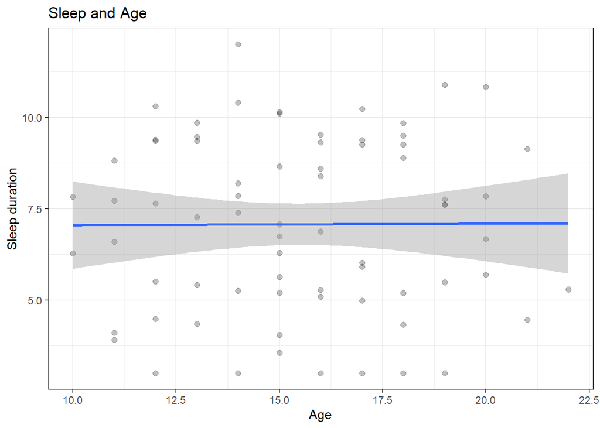

```r
ggplot(data = subset(long_data, id < 16), aes(x = age, y = duration)) +
  geom_point(size = 2, alpha = .25) +
  geom_smooth(method = "lm") +
  xlab("Age") +
  ylab("Sleep duration") +
  ggtitle("Sleep and Age")+
  theme_bw() +
  theme(legend.position = "none")
```

When we have repeated data across participants this assumption no longer holds because observations from the same person may be more highly correlated than observations from different people.

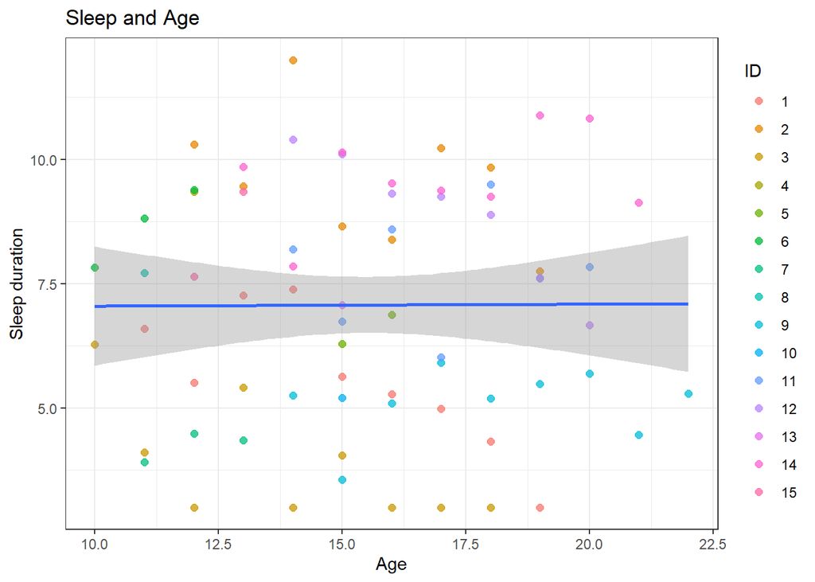

```r
ggplot(data = subset(long_data, id < 16), aes(x = age, y = duration)) +
  geom_point(size = 2, alpha = .75, aes(color = as.factor(id))) +
  geom_smooth(method = "lm") +
  scale_color_discrete("ID")+
  xlab("Age") +
  ylab("Sleep duration") +
  ggtitle("Sleep and Age")+
  theme_bw()
```

Additionally data that is collected across multiple groups, sites, or sometimes days violates this assumption because observations within the group are likely more highly correlated than observations outside the group.

Mixed effect models allow us to group dependent measurements like those from the same person/group.

# Fixed Effects and Random Effects

Mixed effect models are composed of fixed effects and random effects.

Think of fixed effects as the overall estimates we want to get from our model: our predictor and covariates.

The random effects are additional specifications we give the model explaining how to structure the data. Mixed effect models generally consists of random intercepts and random slopes.

In the following equation:

#### *Yij = B0 + B1*xij + B2*xi + b0i + b1i*μij + εij*

*εij = σ<sup>2</sup>0i + σ<sup>2</sup>1ij*

*i* = person level

*j* = observation level

The fixed effects are:

- B0 ~ global intercept
- B1*xij ~ time varying predictor (age, time in study, predictor measured over time)
- B2*xi ~ time invarying predictor (baseline demographics, baseline predictors)

The random effects are:

- b0i ~ random intercept
- b1i*μij ~ random slope on our time-varying predictor

The error terms are:

- σ<sup>2</sup>0i ~ random effect variance (variance between groups)
- σ<sup>2</sup>1ij ~ residual variance (variance within group)

# Building a Mixed Effect Model

To start, we might ask the question, does sleep duration change on average over the follow up?

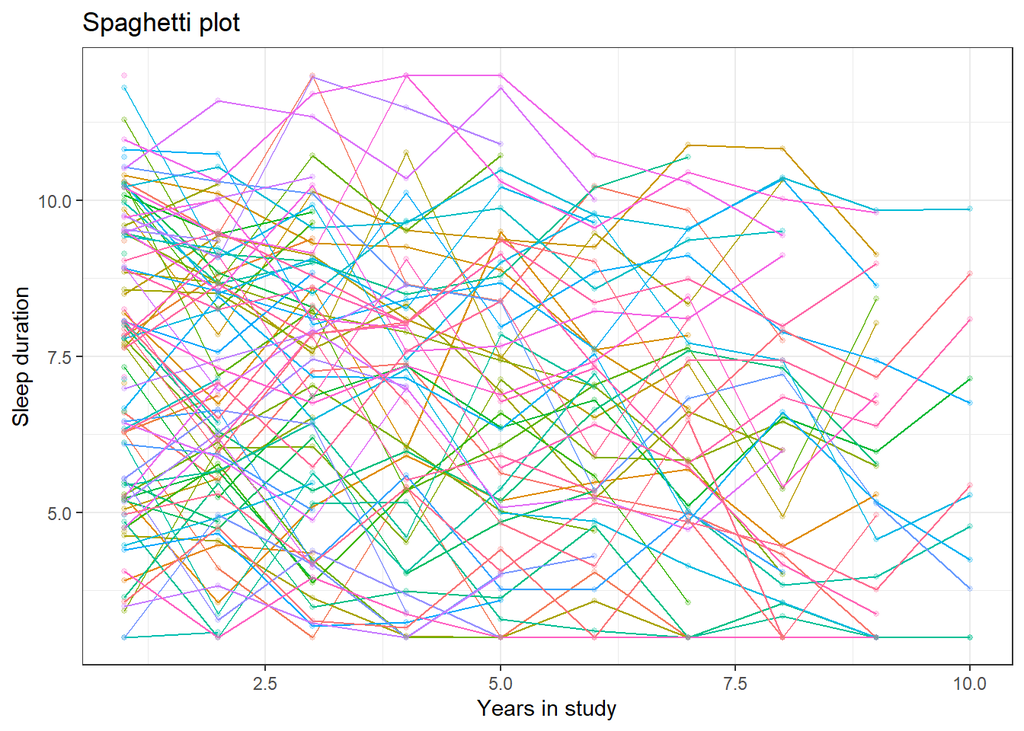

```r
ggplot(data = long_data, aes(x = visit, y = duration, color = factor(id), group = factor(id))) +
  geom_line() +
  geom_point(size = 1, alpha = .25) +
  xlab("Years in study") +
  ylab("Sleep duration") +
  ggtitle("Spaghetti plot")+
  theme_bw() +
  theme(legend.position = "none")
```

We can build a model with sleep duration as our outcome, and visit number as our predictor.

## Random Intercept

Here we specify a random intercept by id using the code (1|id) to tell the model that there is more than 1 observation per id and to group by id.

```r
fit1 <- lmer(duration ~ visit + (1 |id), data = long_data)
summary(fit1)
```

```
## Linear mixed model fit by REML. t-tests use Satterthwaite's method [
## lmerModLmerTest]
## Formula: duration ~ visit + (1 | id)
##    Data: long_data
##
## REML criterion at convergence: 1936.9
##
## Scaled residuals:
##      Min       1Q   Median       3Q      Max
## -2.89106 -0.59998 -0.02648  0.63664  2.70345
##
## Random effects:
##  Groups   Name        Variance Std.Dev.
##  id       (Intercept) 4.247    2.061
##  Residual             1.082    1.040
## Number of obs: 562, groups:  id, 100
##
## Fixed effects:
##              Estimate Std. Error        df t value Pr(>|t|)
## (Intercept)   7.67468    0.22362 119.02175  34.321   <2e-16 ***
## visit        -0.18267    0.01922 479.97096  -9.503   <2e-16 ***
## ---
## Signif. codes:  0 '***' 0.001 '**' 0.01 '*' 0.05 '.' 0.1 ' ' 1
##
## Correlation of Fixed Effects:
##       (Intr)
## visit -0.292
```

To answer our question, does sleep duration change on average over the follow up?

**Yes**, sleep duration is decreasing over time. To interpret the B coefficient we can say: Each year the sleep duration is decreasing by 0.18 hours on average.

To visualize the global trend of our model we can plot it using the plot_model function in sjPlot

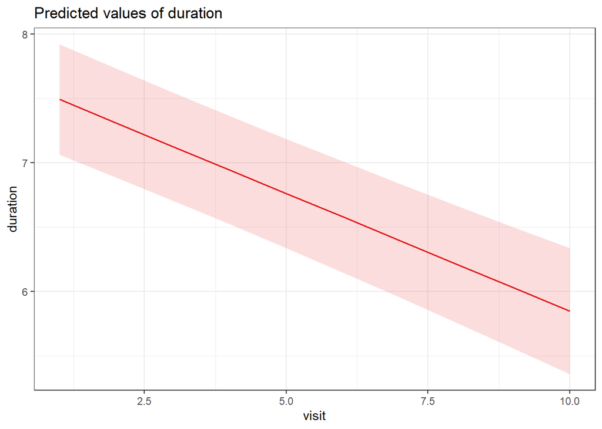

```r
plot_model(fit1, type = "pred") +
  theme_bw()
```

Behind the scenes our model fits each individual with their own beta intercept which we can extract and plot!

```r
#extract random intercepts per id
random_int <- ranef(fit1)$id # this is how far the intercept differs from the global intercept
random_int$id = as.numeric(row.names(random_int))
#join random intercepts with data set
long_data_r_int <- long_data %>%
  full_join(random_int, by = join_by(id))%>%
  mutate(adj_random_int = `(Intercept)` + fit1@beta[1], # adjust random intercepts from global intercept.
         fit.c = predict(fit1, re.form = NULL))# get fitted values for each individual line at all points
head(long_data_r_int) %>%kable()
```

| id | visit | sex | sleep_dx | ses | duration | mood | age | age_bl | (Intercept) | adj_random_int | fit.c |
| --- | --- | --- | --- | --- | --- | --- | --- | --- | --- | --- | --- |
| 1 | 1 | F | 1 | 7 | 6.594244 | 3.954897 | 11 | 11 | -1.177929 | 6.496749 | 6.314076 |
| 1 | 2 | F | 1 | 7 | 5.502200 | 5.644387 | 12 | 11 | -1.177929 | 6.496749 | 6.131402 |
| 1 | 3 | F | 1 | 7 | 7.257461 | 10.000000 | 13 | 11 | -1.177929 | 6.496749 | 5.948729 |
| 1 | 4 | F | 1 | 7 | 7.387598 | 5.569759 | 14 | 11 | -1.177929 | 6.496749 | 5.766055 |
| 1 | 5 | F | 1 | 7 | 5.623388 | 6.422468 | 15 | 11 | -1.177929 | 6.496749 | 5.583381 |
| 1 | 6 | F | 1 | 7 | 5.281096 | 6.049538 | 16 | 11 | -1.177929 | 6.496749 | 5.400708 |

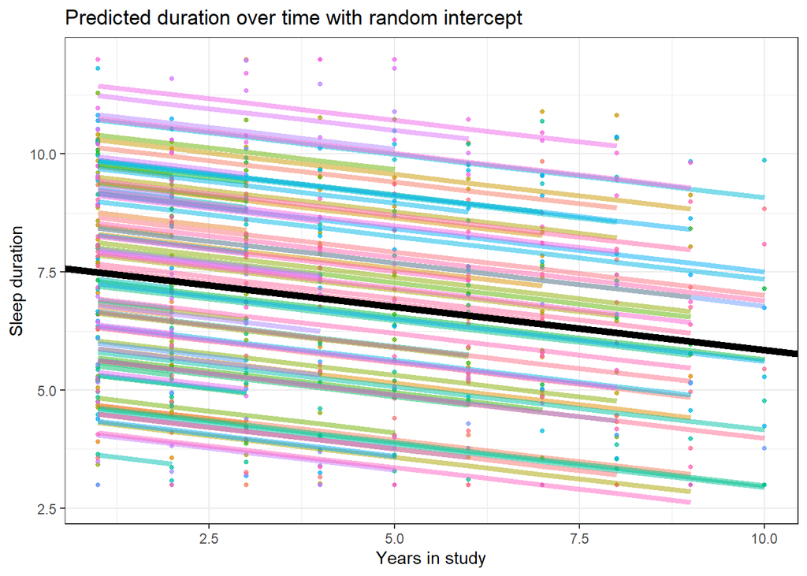

```r
ggplot()+
  geom_point(data = long_data_r_int, aes(x = visit, y = duration, col = factor(id), group = factor(id)), size = 1, alpha = .75) +
  geom_line(data = long_data_r_int, aes(x = visit, y = fit.c, col = factor(id)), size = 1.5, alpha = .5) +
  geom_abline(intercept = fit1@beta[1], slope = fit1@beta[2], color = "black", size = 2) +
  xlab("Years in study") +
  ylab("Sleep duration") +
  ggtitle("Predicted duration over time with random intercept")+
  theme_bw() +
  theme(legend.position = "none")
```

Here we see that mixed effect models can handle different amounts of follow up. Some people have only 1 visit and others have all 10. However, your hypothesis may warrant filtering our participants hwo do not meet a certain threshold.

## Random Intercept and Slope

Additionally, we can specify a random slope using the code (1 + visit |id) to tell the model that each line can also have its own slope based on that individual’s sleep duration trajectory over time.

```r
fit1.1 <- lmer(duration ~ visit + (1 + visit |id), data = long_data)
summary(fit1.1)
```

```
## Linear mixed model fit by REML. t-tests use Satterthwaite's method [
## lmerModLmerTest]
## Formula: duration ~ visit + (1 + visit | id)
##    Data: long_data
##
## REML criterion at convergence: 1890.2
##
## Scaled residuals:
##      Min       1Q   Median       3Q      Max
## -2.30506 -0.61201  0.04738  0.59134  2.49465
##
## Random effects:
##  Groups   Name        Variance Std.Dev. Corr
##  id       (Intercept) 4.5221   2.1265
##           visit       0.0374   0.1934   -0.23
##  Residual             0.8522   0.9232
## Number of obs: 562, groups:  id, 100
##
## Fixed effects:
##             Estimate Std. Error       df t value Pr(>|t|)
## (Intercept)  7.63632    0.22822 99.19203  33.461  < 2e-16 ***
## visit       -0.16612    0.03086 58.96220  -5.384 1.33e-06 ***
## ---
## Signif. codes:  0 '***' 0.001 '**' 0.01 '*' 0.05 '.' 0.1 ' ' 1
##
## Correlation of Fixed Effects:
##       (Intr)
## visit -0.348
```

We still see a similar result that…

**Yes**, sleep duration is (still) decreasing over time. To interpret the B coefficient we can say: Each year the sleep duration is decreasing by 0.17 hours on average.

For this model, we can extract not only an individual B intercept, but also an individual slope per person.

```r
#extract random intercepts per id
random_int <- ranef(fit1.1)$id # this is how far the intercept/slope differs from the fixed intercept/slope
colnames(random_int)[colnames(random_int) == 'visit'] <- 'visit_random'
random_int$id = as.numeric(row.names(random_int))

#join random intercepts with data set
long_data_r_int <- long_data %>%
  full_join(random_int, by = join_by(id))%>%
  mutate(adj_random_int = `(Intercept)` + fit1.1@beta[1], # adjust random intercepts from the fixed intercept
         adj_random_slope_visit = visit_random + fit1.1@beta[2],# adjust random slope from fixed intercept
         fit.c = predict(fit1.1, re.form = NULL))# get fitted values for each individual line at all points
head(long_data_r_int)%>%kable()
```

| id | visit | sex | sleep_dx | ses | duration | mood | age | age_bl | (Intercept) | visit_random | adj_random_int | adj_random_slope_visit | fit.c |
| --- | --- | --- | --- | --- | --- | --- | --- | --- | --- | --- | --- | --- | --- |
| 1 | 1 | F | 1 | 7 | 6.594244 | 3.954897 | 11 | 11 | -0.3328277 | -0.1810232 | 7.303496 | -0.3471424 | 6.956354 |
| 1 | 2 | F | 1 | 7 | 5.502200 | 5.644387 | 12 | 11 | -0.3328277 | -0.1810232 | 7.303496 | -0.3471424 | 6.609211 |
| 1 | 3 | F | 1 | 7 | 7.257461 | 10.000000 | 13 | 11 | -0.3328277 | -0.1810232 | 7.303496 | -0.3471424 | 6.262069 |
| 1 | 4 | F | 1 | 7 | 7.387598 | 5.569759 | 14 | 11 | -0.3328277 | -0.1810232 | 7.303496 | -0.3471424 | 5.914927 |
| 1 | 5 | F | 1 | 7 | 5.623388 | 6.422468 | 15 | 11 | -0.3328277 | -0.1810232 | 7.303496 | -0.3471424 | 5.567784 |
| 1 | 6 | F | 1 | 7 | 5.281096 | 6.049538 | 16 | 11 | -0.3328277 | -0.1810232 | 7.303496 | -0.3471424 | 5.220642 |

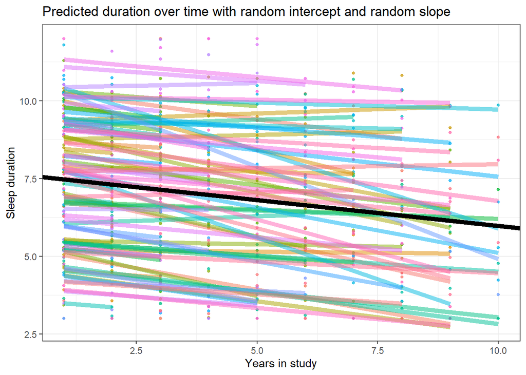

```r
ggplot()+
  geom_point(data = long_data_r_int, aes(x = visit, y = duration, col = factor(id), group = factor(id)), size = 1, alpha = .75) +
  geom_line(data = long_data_r_int, aes(x = visit, y = fit.c, col = factor(id)), size = 2, alpha = .5) +
  geom_abline(intercept = fit1.1@beta[1], slope = fit1.1@beta[2], color = "black", size = 2) +
  xlab("Years in study") +
  ylab("Sleep duration") +
  ggtitle("Predicted duration over time with random intercept and random slope")+
  theme_bw() +
  theme(legend.position = "none")
```

## Output

Now let’s interpret the output we get from the summary() and tab_model() functions.

```r
summary(fit1.1)
```

```
## Linear mixed model fit by REML. t-tests use Satterthwaite's method [
## lmerModLmerTest]
## Formula: duration ~ visit + (1 + visit | id)
##    Data: long_data
##
## REML criterion at convergence: 1890.2
##
## Scaled residuals:
##      Min       1Q   Median       3Q      Max
## -2.30506 -0.61201  0.04738  0.59134  2.49465
##
## Random effects:
##  Groups   Name        Variance Std.Dev. Corr
##  id       (Intercept) 4.5221   2.1265
##           visit       0.0374   0.1934   -0.23
##  Residual             0.8522   0.9232
## Number of obs: 562, groups:  id, 100
##
## Fixed effects:
##             Estimate Std. Error       df t value Pr(>|t|)
## (Intercept)  7.63632    0.22822 99.19203  33.461  < 2e-16 ***
## visit       -0.16612    0.03086 58.96220  -5.384 1.33e-06 ***
## ---
## Signif. codes:  0 '***' 0.001 '**' 0.01 '*' 0.05 '.' 0.1 ' ' 1
##
## Correlation of Fixed Effects:
##       (Intr)
## visit -0.348
```

```r
tab_model(fit1.1)
```

|  | duration |  |  |
| --- | --- | --- | --- |
| Predictors | Estimates | CI | p |
| (Intercept) | 7.64 | 7.19 – 8.08 | **<0.001** |
| visit | -0.17 | -0.23 – -0.11 | **<0.001** |
| Random Effects |  |  |  |
| σ<sup>2</sup> | 0.85 |  |  |
| τ<sub>00</sub> <sub>id</sub> | 4.52 |  |  |
| τ<sub>11</sub> <sub>id.visit</sub> | 0.04 |  |  |
| ρ<sub>01</sub> <sub>id</sub> | -0.23 |  |  |
| ICC | 0.84 |  |  |
| N <sub>id</sub> | 100 |  |  |
| Observations | 562 |  |  |
| Marginal R<sup>2</sup> / Conditional R<sup>2</sup> | 0.033 / 0.850 |  |  |

**σ<sup>2</sup>** = residual variance (the within person variability)

**τ00** = variance of random intercept

**τ11** = variance of random slope

**ρ01** = correlation between random intercept and slope (the amount of covariance between intercept and slope is due to their shared variation)

**ICC** = is the proportion of the variance explained by the grouping structure in the population:

Remember our error terms we specified above?

Error:

- *σ<sup>2</sup>0i ~ random effect variance (variance between groups)*
- *σ<sup>2</sup>1ij ~ residual variance (variance within group)*

ICC = σ<sup>2</sup>0i / (σ<sup>2</sup>0i + σ<sup>2</sup>1ij)

Low ICC:

An ICC close to 0 (or <0.4) indicates that most of the variability is within person and within person measurements are not more highly correlated compared to measurements from other people. This may provide evidence that a mixed effect framework is not need, however with repeated measures from the same person, a mixed effect model is strongly advised.

High ICC:

An ICC close to 1 indicates that most of the variability is between person. This provides evidence that the mixed effect framework is necessary.

From the performance package you can calculate it using the function icc().

```r
icc(fit1.1)
```

```
## # Intraclass Correlation Coefficient
##
##     Adjusted ICC: 0.844
##   Unadjusted ICC: 0.817
```

Usually we care about the adjusted ICC.

**N** = number of participants

**Marginal R<sup>2</sup>** = the amount of variance explained by the fixed effects

**Conditional R<sup>2</sup>** = the amount of variance explained by the fixed and random effect.

Usually we care about the conditional R<sup>2</sup>.

# Interactions in Mixed effect Models

Sometimes we are interested in how one variable affects another variable’s relationship with the outcome. In psychology we often call this *moderation*.

Below are some examples of when to add interactions and how to interpret the B coefficients.

## Time interaction

Does the change in sleep duration over the follow up differ between those with and without a sleep disorder diagnosis?

What we are asking mathematically is, *Is there a difference in the slope of duration over time in between the sleep diagnosis groups?*

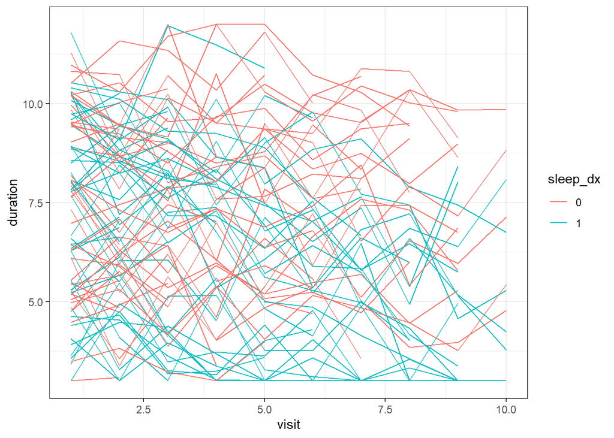

```r
ggplot(data = long_data, aes(x = visit, y = duration, color = sleep_dx, group = factor(id))) +
  geom_line() +
  theme_bw()
```

```r
fit2 <- lmer(duration ~ visit + sleep_dx + sex + visit*sleep_dx +(1 + visit |id), data = long_data)
summary(fit2)
```

```
## Linear mixed model fit by REML. t-tests use Satterthwaite's method [
## lmerModLmerTest]
## Formula: duration ~ visit + sleep_dx + sex + visit * sleep_dx + (1 + visit |
##     id)
##    Data: long_data
##
## REML criterion at convergence: 1857.4
##
## Scaled residuals:
##      Min       1Q   Median       3Q      Max
## -2.73196 -0.60332  0.04712  0.59659  2.48559
##
## Random effects:
##  Groups   Name        Variance Std.Dev. Corr
##  id       (Intercept) 4.74915  2.1793
##           visit       0.01294  0.1138   -0.54
##  Residual             0.86661  0.9309
## Number of obs: 562, groups:  id, 100
##
## Fixed effects:
##                  Estimate Std. Error        df t value Pr(>|t|)
## (Intercept)       7.69847    0.35664 103.79869  21.586  < 2e-16 ***
## visit            -0.01639    0.03205  58.50092  -0.511    0.611
## sleep_dx1         0.47035    0.46911  97.69280   1.003    0.319
## sexM             -0.67641    0.41749  94.21553  -1.620    0.109
## visit:sleep_dx1  -0.30725    0.04495  54.72681  -6.835 7.18e-09 ***
## ---
## Signif. codes:  0 '***' 0.001 '**' 0.01 '*' 0.05 '.' 0.1 ' ' 1
##
## Correlation of Fixed Effects:
##             (Intr) visit  slp_d1 sexM
## visit       -0.438
## sleep_dx1   -0.574  0.332
## sexM        -0.409  0.003 -0.143
## vst:slp_dx1  0.319 -0.713 -0.472 -0.018
```

Yes! Those with a sleep diagnosis have a 0.31 hour decrease on average in duration per year compared to those without a sleep diagnosis.

Let’s visualize the interaction:

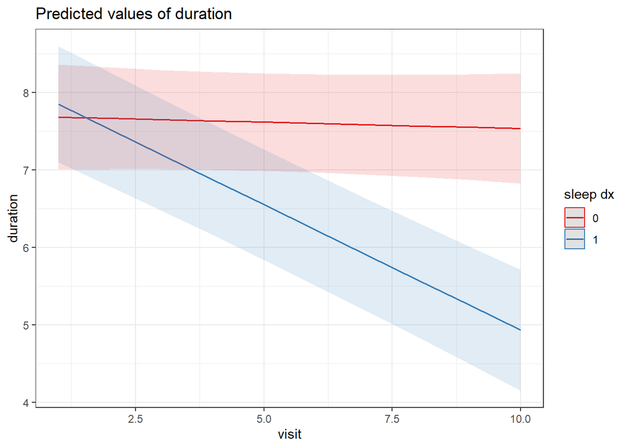

```r
plot_model(fit2, type = "int") +
  theme_bw()
```

The graph shows us that those with a sleep disorder diagnosis have a decreasing duration over time and those with no sleep disorder have constant sleep over time.

Note: the coefficient tells us about the DIFFERENCE in slopes, but the graph tells us the direction of the change.

## 2 Categorical Interaction

Do sleep disorders have a greater affect on duration for female participants compared to male?

```r
fit3 <- lmer(duration ~ visit + sleep_dx + sex + sex*sleep_dx +(1 + visit |id), data = long_data)
summary(fit3)
```

```
## Linear mixed model fit by REML. t-tests use Satterthwaite's method [
## lmerModLmerTest]
## Formula: duration ~ visit + sleep_dx + sex + sex * sleep_dx + (1 + visit |
##     id)
##    Data: long_data
##
## REML criterion at convergence: 1882.7
##
## Scaled residuals:
##      Min       1Q   Median       3Q      Max
## -2.29633 -0.60391  0.03825  0.58677  2.50071
##
## Random effects:
##  Groups   Name        Variance Std.Dev. Corr
##  id       (Intercept) 4.72906  2.175
##           visit       0.03688  0.192    -0.37
##  Residual             0.85376  0.924
## Number of obs: 562, groups:  id, 100
##
## Fixed effects:
##                 Estimate Std. Error        df t value Pr(>|t|)
## (Intercept)      8.40129    0.37899 103.25388  22.167  < 2e-16 ***
## visit           -0.16627    0.03042  58.98423  -5.466 9.75e-07 ***
## sleep_dx1       -1.05529    0.56573  96.00474  -1.865   0.0652 .
## sexM            -1.30800    0.61913  96.68048  -2.113   0.0372 *
## sleep_dx1:sexM   1.25058    0.86340  96.06698   1.448   0.1507
## ---
## Signif. codes:  0 '***' 0.001 '**' 0.01 '*' 0.05 '.' 0.1 ' ' 1
##
## Correlation of Fixed Effects:
##             (Intr) visit  slp_d1 sexM
## visit       -0.266
## sleep_dx1   -0.625  0.011
## sexM        -0.572  0.011  0.381
## slp_dx1:sxM  0.413 -0.020 -0.655 -0.717
```

No significant effect.

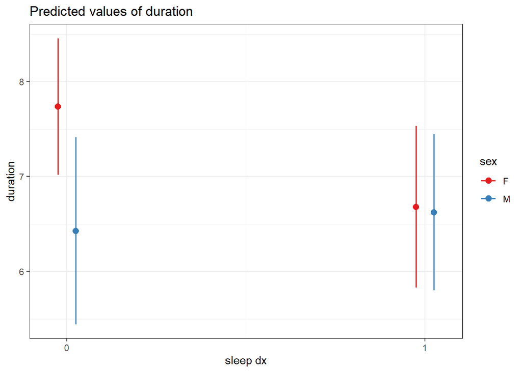

```r
plot_model(fit3, type = "int") +
  theme_bw()
```

The difference in sleep duration for those with a sleep disorder diagnosis is 1.3 hours greater in male participants compared to female participants. This was not found to be statistically significant.

## 1 Categorical, 1 Continuous Interaction

Is sleep duration more strongly influenced by baseline SES in those with a sleep disorder diagnosis compared to those without a diagnosis?

```r
fit4 <- lmer(duration ~ visit + ses+ sleep_dx + sex  + ses*sleep_dx +(1 + visit |id), data = long_data)
summary(fit4)
```

```
## Linear mixed model fit by REML. t-tests use Satterthwaite's method [
## lmerModLmerTest]
## Formula: duration ~ visit + ses + sleep_dx + sex + ses * sleep_dx + (1 +
##     visit | id)
##    Data: long_data
##
## REML criterion at convergence: 1890
##
## Scaled residuals:
##     Min      1Q  Median      3Q     Max
## -2.2938 -0.6187  0.0405  0.5881  2.4924
##
## Random effects:
##  Groups   Name        Variance Std.Dev. Corr
##  id       (Intercept) 4.8230   2.1961
##           visit       0.0369   0.1921   -0.38
##  Residual             0.8536   0.9239
## Number of obs: 562, groups:  id, 100
##
## Fixed effects:
##               Estimate Std. Error       df t value Pr(>|t|)
## (Intercept)    8.25609    0.61583 97.35613  13.406  < 2e-16 ***
## visit         -0.16475    0.03040 59.34145  -5.420 1.14e-06 ***
## ses           -0.01765    0.10234 93.00851  -0.172    0.863
## sleep_dx1     -1.40049    0.90098 93.46614  -1.554    0.123
## sexM          -0.62290    0.43761 94.97170  -1.423    0.158
## ses:sleep_dx1  0.15120    0.14409 95.18858   1.049    0.297
## ---
## Signif. codes:  0 '***' 0.001 '**' 0.01 '*' 0.05 '.' 0.1 ' ' 1
##
## Correlation of Fixed Effects:
##             (Intr) visit  ses    slp_d1 sexM
## visit       -0.167
## ses         -0.825  0.006
## sleep_dx1   -0.615 -0.008  0.592
## sexM        -0.163 -0.004 -0.098 -0.183
## ses:slp_dx1  0.576  0.007 -0.715 -0.877  0.119
```

No they are the same.

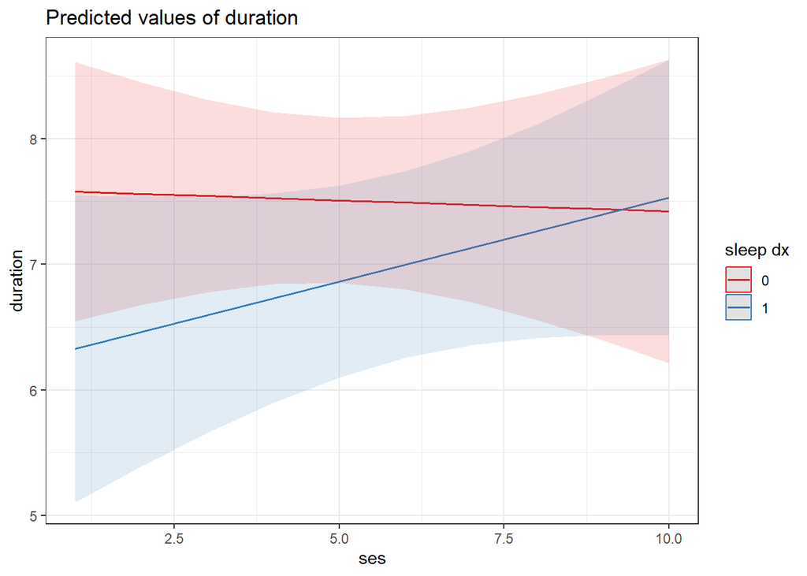

```r
plot_model(fit4, type = "int") +
  theme_bw()
```

Participants with a sleep disorder diagnosis sleep 0.15 hours longer for every 1 unit increase in SES compared to those without a sleep disorder diagnosis. This was not found to be statistically significant.

(The slope of the line for sleep diagnosis (blue) is 0.15 greater than the slope of the line for no sleep diagnosis (red).)

## 2 Continuous Interaction

How does baseline age affect the relationship between sleep duration and social economic status?

```r
fit5 <- lmer(duration ~ visit + ses+ sleep_dx + sex  + age_bl + ses*age_bl +(1 + visit |id), data = long_data)
summary(fit5)
```

```
## Linear mixed model fit by REML. t-tests use Satterthwaite's method [
## lmerModLmerTest]
## Formula: duration ~ visit + ses + sleep_dx + sex + age_bl + ses * age_bl +
##     (1 + visit | id)
##    Data: long_data
##
## REML criterion at convergence: 1894.8
##
## Scaled residuals:
##      Min       1Q   Median       3Q      Max
## -2.29036 -0.60377  0.03677  0.59181  2.49089
##
## Random effects:
##  Groups   Name        Variance Std.Dev. Corr
##  id       (Intercept) 4.93443  2.2214
##           visit       0.03671  0.1916   -0.40
##  Residual             0.85407  0.9242
## Number of obs: 562, groups:  id, 100
##
## Fixed effects:
##             Estimate Std. Error       df t value Pr(>|t|)
## (Intercept) 11.24715    3.33835 92.39939   3.369   0.0011 **
## visit       -0.16516    0.03030 59.33309  -5.450 1.02e-06 ***
## ses         -0.36843    0.53239 95.97185  -0.692   0.4906
## sleep_dx1   -0.65461    0.43772 93.37551  -1.495   0.1382
## sexM        -0.69427    0.43824 94.06047  -1.584   0.1165
## age_bl      -0.27075    0.26705 92.22502  -1.014   0.3133
## ses:age_bl   0.03472    0.04178 95.33745   0.831   0.4080
## ---
## Signif. codes:  0 '***' 0.001 '**' 0.01 '*' 0.05 '.' 0.1 ' ' 1
##
## Correlation of Fixed Effects:
##            (Intr) visit  ses    slp_d1 sexM   age_bl
## visit      -0.043
## ses        -0.872  0.024
## sleep_dx1  -0.148 -0.004  0.061
## sexM       -0.043 -0.007 -0.042 -0.162
## age_bl     -0.988  0.010  0.860  0.108  0.001
## ses:age_bl  0.881 -0.021 -0.990 -0.079  0.037 -0.885
```

No effect.

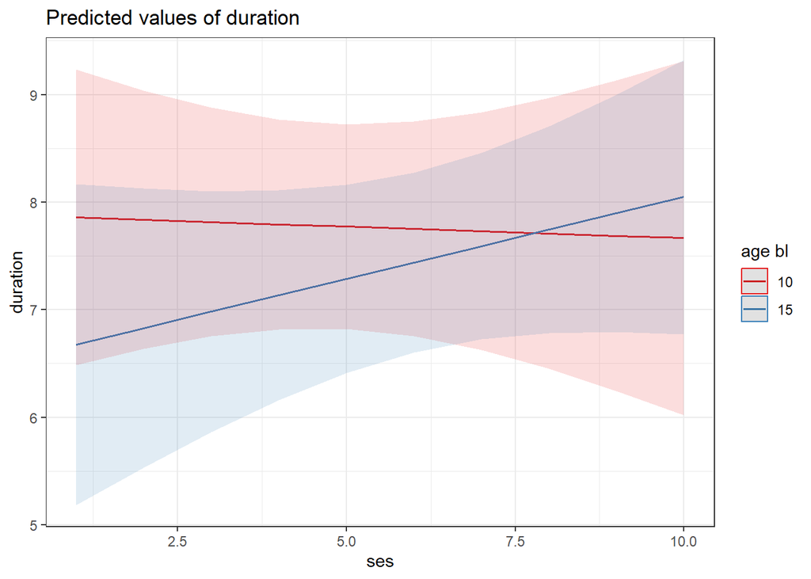

```r
plot_model(fit5, type = "int") +
  theme_bw()
```

For every one year increase in baseline age, sleep duration increases by 0.03 hours for each 1 unit increase in SES. This was not found to be statistically significant.

(The slope between SES and sleep increases by 0.03 for every 1 year increase in baseline age.)

# Separating Within and Between Person Effects

## Cross sectional models

Now we are interested in the relationship between duration and mood, which are both measured at each time point.

We can plot mood over time by id.

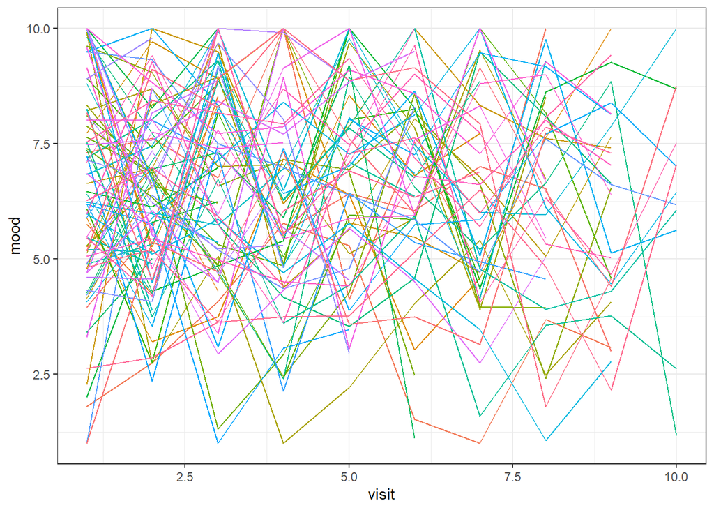

```r
ggplot(data = long_data, aes(x = visit, y = mood, color = factor(id), group = factor(id))) +
  geom_line() +
  theme_bw() +
  theme(legend.position = "none")
```

We can plot the relationship between duration and mood by id

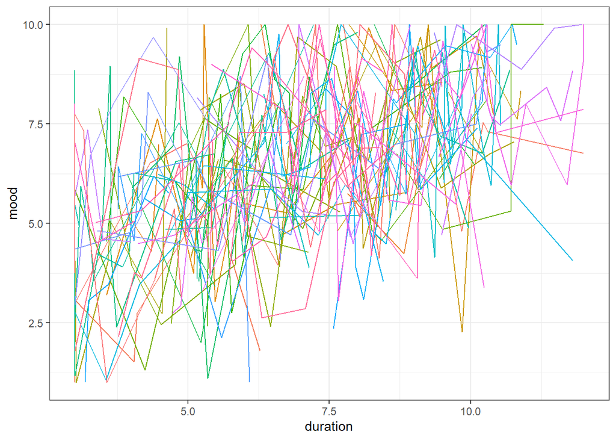

```r
ggplot(data = long_data, aes(x = duration, y = mood, color = factor(id), group = factor(id))) +
  geom_line() +
  theme_bw() +
  theme(legend.position = "none")
```

It looks like mood and duration are related, so we can test that using a mixed effect model.

```r
fit6 <- lmer(mood ~ duration + sleep_dx + sex + visit + (1 + duration |id), data = long_data)
```

```
## boundary (singular) fit: see help('isSingular')
```

```r
summary(fit6)
```

```
## Linear mixed model fit by REML. t-tests use Satterthwaite's method [
## lmerModLmerTest]
## Formula: mood ~ duration + sleep_dx + sex + visit + (1 + duration | id)
##    Data: long_data
##
## REML criterion at convergence: 2314.9
##
## Scaled residuals:
##      Min       1Q   Median       3Q      Max
## -2.86480 -0.68645  0.01279  0.71193  2.71929
##
## Random effects:
##  Groups   Name        Variance Std.Dev. Corr
##  id       (Intercept) 0.9372   0.9681
##           duration    0.0110   0.1049   -1.00
##  Residual             3.4309   1.8523
## Number of obs: 562, groups:  id, 100
##
## Fixed effects:
##              Estimate Std. Error        df t value Pr(>|t|)
## (Intercept)   2.76446    0.38348 163.33262   7.209 1.98e-11 ***
## duration      0.48428    0.03945 142.80561  12.275  < 2e-16 ***
## sleep_dx1    -0.06055    0.17737 209.73055  -0.341   0.7332
## sexM          0.23866    0.17788 186.63782   1.342   0.1813
## visit         0.06062    0.03138 545.56079   1.932   0.0539 .
## ---
## Signif. codes:  0 '***' 0.001 '**' 0.01 '*' 0.05 '.' 0.1 ' ' 1
##
## Correlation of Fixed Effects:
##           (Intr) duratn slp_d1 sexM
## duration  -0.882
## sleep_dx1 -0.341  0.190
## sexM      -0.270  0.150 -0.181
## visit     -0.472  0.170  0.043 -0.006
## optimizer (nloptwrap) convergence code: 0 (OK)
## boundary (singular) fit: see help('isSingular')
```

Notice, we also get a warning, boundary (singular) fit: see help(‘isSingular’). This tells us that the model is over fitted and we may have too many random effects. Essentially there is not a big enough difference in one of the random effects across all the ids to be necessary in the model.

Let’s refit the model without the random slope.

```r
fit6 <- lmer(mood ~ duration + sleep_dx + sex + visit + (1 |id), data = long_data)
summary(fit6)
```

```
## Linear mixed model fit by REML. t-tests use Satterthwaite's method [
## lmerModLmerTest]
## Formula: mood ~ duration + sleep_dx + sex + visit + (1 | id)
##    Data: long_data
##
## REML criterion at convergence: 2318.6
##
## Scaled residuals:
##      Min       1Q   Median       3Q      Max
## -2.85715 -0.69725  0.00444  0.69140  2.56148
##
## Random effects:
##  Groups   Name        Variance Std.Dev.
##  id       (Intercept) 0.04934  0.2221
##  Residual             3.50392  1.8719
## Number of obs: 562, groups:  id, 100
##
## Fixed effects:
##              Estimate Std. Error        df t value Pr(>|t|)
## (Intercept)   2.79375    0.36324 169.97778   7.691 1.12e-12 ***
## duration      0.48500    0.03734 138.62788  12.989  < 2e-16 ***
## sleep_dx1    -0.04217    0.17391  85.73513  -0.243   0.8090
## sexM          0.14398    0.17276  79.65894   0.833   0.4071
## visit         0.05837    0.03130 546.07218   1.865   0.0627 .
## ---
## Signif. codes:  0 '***' 0.001 '**' 0.01 '*' 0.05 '.' 0.1 ' ' 1
##
## Correlation of Fixed Effects:
##           (Intr) duratn slp_d1 sexM
## duration  -0.868
## sleep_dx1 -0.372  0.223
## sexM      -0.278  0.152 -0.162
## visit     -0.505  0.194  0.024 -0.003
```

When we run it again without the random slope, the warning goes away.

So what do the results tell us?

As **AVERAGE** duration increases, so does **AVERAGE** mood.

But, this does NOT tell us if that change is happening within person or between person. To do this, we must separate out the within and between person effects.

```r
long_data_within_btwn <- long_data %>%
  group_by(id) %>%
  mutate(btwn_dur = mean(duration),  # mean duration for each person (repeated over time)
         wthin_dur = duration - btwn_dur) # individual's deviation from the mean

head(long_data_within_btwn) %>%kable()
```

| id | visit | sex | sleep_dx | ses | duration | mood | age | age_bl | btwn_dur | wthin_dur |
| --- | --- | --- | --- | --- | --- | --- | --- | --- | --- | --- |
| 1 | 1 | F | 1 | 7 | 6.594244 | 3.954897 | 11 | 11 | 5.550039 | 1.0442044 |
| 1 | 2 | F | 1 | 7 | 5.502200 | 5.644387 | 12 | 11 | 5.550039 | -0.0478388 |
| 1 | 3 | F | 1 | 7 | 7.257461 | 10.000000 | 13 | 11 | 5.550039 | 1.7074213 |
| 1 | 4 | F | 1 | 7 | 7.387598 | 5.569759 | 14 | 11 | 5.550039 | 1.8375584 |
| 1 | 5 | F | 1 | 7 | 5.623388 | 6.422468 | 15 | 11 | 5.550039 | 0.0733489 |
| 1 | 6 | F | 1 | 7 | 5.281096 | 6.049538 | 16 | 11 | 5.550039 | -0.2689434 |

Between person is a repeated measure of the average and within person is the deviation from that average.

```r
fit6.1 <- lmer(mood ~ wthin_dur + btwn_dur + sleep_dx + sex + visit + (1 |id), data = long_data_within_btwn)
summary(fit6.1)
```

```
## Linear mixed model fit by REML. t-tests use Satterthwaite's method [
## lmerModLmerTest]
## Formula: mood ~ wthin_dur + btwn_dur + sleep_dx + sex + visit + (1 | id)
##    Data: long_data_within_btwn
##
## REML criterion at convergence: 2321.2
##
## Scaled residuals:
##      Min       1Q   Median       3Q      Max
## -2.84187 -0.68390  0.00372  0.70322  2.53433
##
## Random effects:
##  Groups   Name        Variance Std.Dev.
##  id       (Intercept) 0.04989  0.2234
##  Residual             3.50796  1.8730
## Number of obs: 562, groups:  id, 100
##
## Fixed effects:
##              Estimate Std. Error        df t value Pr(>|t|)
## (Intercept)   2.85008    0.37830 123.81594   7.534 8.97e-12 ***
## wthin_dur     0.52441    0.08205 507.89997   6.392 3.72e-10 ***
## btwn_dur      0.47496    0.04175  91.20246  11.376  < 2e-16 ***
## sleep_dx1    -0.05332    0.17532  85.09033  -0.304    0.762
## sexM          0.13569    0.17362  78.75655   0.781    0.437
## visit         0.06372    0.03286 547.69601   1.939    0.053 .
## ---
## Signif. codes:  0 '***' 0.001 '**' 0.01 '*' 0.05 '.' 0.1 ' ' 1
##
## Correlation of Fixed Effects:
##           (Intr) wthn_d btwn_d slp_d1 sexM
## wthin_dur -0.134
## btwn_dur  -0.870  0.011
## sleep_dx1 -0.388 -0.005  0.251
## sexM      -0.291 -0.010  0.175 -0.150
## visit     -0.379  0.354  0.031 -0.013 -0.030
```

Within person: For every 1 hour that someone sleeps more than their average, the mood score increases by 0.52.

Between person: For every 1 hour on average that some sleeps compared to their peer, the mood score increases by 0.47.

## Predictive models

With longitudinal data, we can reformat the data to predict a future outcome. Here we pair current sleep with next year’s mood.

```r
# reformat data to pair depression with next years mood.
mood_next_year <- long_data_within_btwn %>%
  select(id, visit, mood)%>%
  mutate(visit_cs = visit, # cross sectional visit
         visit = visit - 1,
         mood_next_year = mood) %>%
  select( - mood)
long_data_pred <- full_join(long_data_within_btwn, mood_next_year, by = join_by(id, visit))

head(long_data_pred) %>% kable()
```

| id | visit | sex | sleep_dx | ses | duration | mood | age | age_bl | btwn_dur | wthin_dur | visit_cs | mood_next_year |
| --- | --- | --- | --- | --- | --- | --- | --- | --- | --- | --- | --- | --- |
| 1 | 1 | F | 1 | 7 | 6.594244 | 3.954897 | 11 | 11 | 5.550039 | 1.0442044 | 2 | 5.644387 |
| 1 | 2 | F | 1 | 7 | 5.502200 | 5.644387 | 12 | 11 | 5.550039 | -0.0478388 | 3 | 10.000000 |
| 1 | 3 | F | 1 | 7 | 7.257461 | 10.000000 | 13 | 11 | 5.550039 | 1.7074213 | 4 | 5.569759 |
| 1 | 4 | F | 1 | 7 | 7.387598 | 5.569759 | 14 | 11 | 5.550039 | 1.8375584 | 5 | 6.422468 |
| 1 | 5 | F | 1 | 7 | 5.623388 | 6.422468 | 15 | 11 | 5.550039 | 0.0733489 | 6 | 6.049538 |
| 1 | 6 | F | 1 | 7 | 5.281096 | 6.049538 | 16 | 11 | 5.550039 | -0.2689434 | 7 | 7.003266 |

```r
fit7 <- lmer(mood_next_year ~ wthin_dur + btwn_dur + mood +  (1 |id), data = long_data_pred)
summary(fit7)
```

```
## Linear mixed model fit by REML. t-tests use Satterthwaite's method [
## lmerModLmerTest]
## Formula: mood_next_year ~ wthin_dur + btwn_dur + mood + (1 | id)
##    Data: long_data_pred
##
## REML criterion at convergence: 1911.7
##
## Scaled residuals:
##      Min       1Q   Median       3Q      Max
## -2.48773 -0.70722 -0.01197  0.76014  2.48796
##
## Random effects:
##  Groups   Name        Variance Std.Dev.
##  id       (Intercept) 0.1407   0.3751
##  Residual             3.4600   1.8601
## Number of obs: 462, groups:  id, 86
##
## Fixed effects:
##              Estimate Std. Error        df t value Pr(>|t|)
## (Intercept)   3.25003    0.36980  88.26839   8.789 1.09e-13 ***
## wthin_dur     0.28400    0.08743 405.90468   3.248  0.00126 **
## btwn_dur      0.48136    0.05057  90.74065   9.519 2.66e-15 ***
## mood         -0.02458    0.04627 457.99422  -0.531  0.59546
## ---
## Signif. codes:  0 '***' 0.001 '**' 0.01 '*' 0.05 '.' 0.1 ' ' 1
##
## Correlation of Fixed Effects:
##           (Intr) wthn_d btwn_d
## wthin_dur  0.077
## btwn_dur  -0.625  0.116
## mood      -0.424 -0.252 -0.399
```

While adjusting for current mood, every 1 hour that some sleeps more than their average, next year’s mood increases by 0.28.

While adjusting for current mood, every 1 hour that some sleeps on average more than their peers, next year’s mood increases by 0.48.

# Other distributions

When we have other types of outcomes, we can use other distributions to model the data.

```r
#create new data
long_data_dist <- long_data_within_btwn  %>%
  group_by(id) %>%
  mutate(
    site = sample(c("home", "lab"), size = 1)
  ) %>%
  ungroup() %>%
  mutate(
    # Add a negative intercept to lower overall probability
    prob_depression = plogis(-2 + (-0.8 * scale(mood))),

    depression = rbinom(n(), size = 1, prob = prob_depression),

    MH_count = pmin(rpois(n(), lambda = 3), 13)
  ) %>%
  select(-prob_depression)
```

```r
head(long_data_dist) %>% kable()
```

| id | visit | sex | sleep_dx | ses | duration | mood | age | age_bl | btwn_dur | wthin_dur | site | depression | MH_count |
| --- | --- | --- | --- | --- | --- | --- | --- | --- | --- | --- | --- | --- | --- |
| 1 | 1 | F | 1 | 7 | 6.594244 | 3.954897 | 11 | 11 | 5.550039 | 1.0442044 | lab | 1 | 2 |
| 1 | 2 | F | 1 | 7 | 5.502200 | 5.644387 | 12 | 11 | 5.550039 | -0.0478388 | lab | 0 | 2 |
| 1 | 3 | F | 1 | 7 | 7.257461 | 10.000000 | 13 | 11 | 5.550039 | 1.7074213 | lab | 0 | 2 |
| 1 | 4 | F | 1 | 7 | 7.387598 | 5.569759 | 14 | 11 | 5.550039 | 1.8375584 | lab | 0 | 3 |
| 1 | 5 | F | 1 | 7 | 5.623388 | 6.422468 | 15 | 11 | 5.550039 | 0.0733489 | lab | 1 | 4 |
| 1 | 6 | F | 1 | 7 | 5.281096 | 6.049538 | 16 | 11 | 5.550039 | -0.2689434 | lab | 1 | 1 |

If we expand our study to include an measure for depression indicator and mental health risk count at each time point, we can explore mixed effect models with other distributions

## Logistic

When we have a binary outcome, like depression here, we can use a logistic regression model with the glmer function. This runs a generalized linear mixed effect model, where the family indicates the distribution.

```r
fit8 <- glmer(depression ~ wthin_dur + btwn_dur + sex + (1 |id), family = binomial(link = "logit"), data = long_data_dist)
summary(fit8)
```

```
## Generalized linear mixed model fit by maximum likelihood (Laplace
##   Approximation) [glmerMod]
##  Family: binomial  ( logit )
## Formula: depression ~ wthin_dur + btwn_dur + sex + (1 | id)
##    Data: long_data_dist
##
##       AIC       BIC    logLik -2*log(L)  df.resid
##     488.9     510.5    -239.4     478.9       557
##
## Scaled residuals:
##     Min      1Q  Median      3Q     Max
## -0.6864 -0.4420 -0.3753 -0.3190  3.1766
##
## Random effects:
##  Groups Name        Variance Std.Dev.
##  id     (Intercept) 0.2398   0.4897
## Number of obs: 562, groups:  id, 100
##
## Fixed effects:
##             Estimate Std. Error z value Pr(>|z|)
## (Intercept) -0.70217    0.48768  -1.440   0.1499
## wthin_dur   -0.13527    0.11475  -1.179   0.2385
## btwn_dur    -0.14602    0.06511  -2.243   0.0249 *
## sexM        -0.16284    0.27293  -0.597   0.5507
## ---
## Signif. codes:  0 '***' 0.001 '**' 0.01 '*' 0.05 '.' 0.1 ' ' 1
##
## Correlation of Fixed Effects:
##           (Intr) wthn_d btwn_d
## wthin_dur  0.007
## btwn_dur  -0.927  0.016
## sexM      -0.427  0.013  0.220
```

Because logistic models use a logit link, the B coefficients need to exponentiated to be interpretable.

e<sup>B</sup>

We can do this with the tidy() function, or the tab_model() function.

```r
tidy(fit8, conf.int = TRUE, exponentiate = TRUE, effects = "fixed")
```

```
## # A tibble: 4 × 8
##   effect term        estimate std.error statistic p.value conf.low conf.high
##   <chr>  <chr>          <dbl>     <dbl>     <dbl>   <dbl>    <dbl>     <dbl>
## 1 fixed  (Intercept)    0.496    0.242     -1.44   0.150     0.191     1.29
## 2 fixed  wthin_dur      0.873    0.100     -1.18   0.238     0.698     1.09
## 3 fixed  btwn_dur       0.864    0.0563    -2.24   0.0249    0.761     0.982
## 4 fixed  sexM           0.850    0.232     -0.597  0.551     0.498     1.45
```

```r
tab_model(fit8)
```

|  | depression |  |  |
| --- | --- | --- | --- |
| Predictors | Odds Ratios | CI | p |
| (Intercept) | 0.50 | 0.19 – 1.29 | 0.150 |
| wthin dur | 0.87 | 0.70 – 1.09 | 0.238 |
| btwn dur | 0.86 | 0.76 – 0.98 | **0.025** |
| sex [M] | 0.85 | 0.50 – 1.45 | 0.551 |
| Random Effects |  |  |  |
| σ<sup>2</sup> | 3.29 |  |  |
| τ<sub>00</sub> <sub>id</sub> | 0.24 |  |  |
| ICC | 0.07 |  |  |
| N <sub>id</sub> | 100 |  |  |
| Observations | 562 |  |  |
| Marginal R<sup>2</sup> / Conditional R<sup>2</sup> | 0.030 / 0.096 |  |  |

For every one hour more someone sleep compared to their peer, their risk for depression decreases by 14%.

(1-0.86 = 0.14)

## Poisson/Negative Binomial

When we have a count outcome, like mental health risk, we can use either a Poisson or Negative Binomial regression model.

### Poisson

```r
fit9 <- glmer(MH_count ~ wthin_dur + btwn_dur  + (1 |id), family = poisson(link = "log"), data = long_data_dist)
summary(fit9)
```

```
## Generalized linear mixed model fit by maximum likelihood (Laplace
##   Approximation) [glmerMod]
##  Family: poisson  ( log )
## Formula: MH_count ~ wthin_dur + btwn_dur + (1 | id)
##    Data: long_data_dist
##
##       AIC       BIC    logLik -2*log(L)  df.resid
##    2152.4    2169.7   -1072.2    2144.4       558
##
## Scaled residuals:
##     Min      1Q  Median      3Q     Max
## -1.7517 -0.5916  0.0128  0.6298  3.4624
##
## Random effects:
##  Groups Name        Variance  Std.Dev.
##  id     (Intercept) 0.0002203 0.01484
## Number of obs: 562, groups:  id, 100
##
## Fixed effects:
##             Estimate Std. Error z value Pr(>|z|)
## (Intercept)  1.15261    0.08419  13.691   <2e-16 ***
## wthin_dur   -0.01066    0.02388  -0.446    0.655
## btwn_dur    -0.01054    0.01173  -0.899    0.369
## ---
## Signif. codes:  0 '***' 0.001 '**' 0.01 '*' 0.05 '.' 0.1 ' ' 1
##
## Correlation of Fixed Effects:
##           (Intr) wthn_d
## wthin_dur  0.003
## btwn_dur  -0.955  0.000
```

```r
tidy(fit9, conf.int = TRUE, exponentiate = TRUE, effects = "fixed")
```

```
## # A tibble: 3 × 8
##   effect term        estimate std.error statistic  p.value conf.low conf.high
##   <chr>  <chr>          <dbl>     <dbl>     <dbl>    <dbl>    <dbl>     <dbl>
## 1 fixed  (Intercept)    3.17     0.267     13.7   1.15e-42    2.68       3.73
## 2 fixed  wthin_dur      0.989    0.0236    -0.446 6.55e- 1    0.944      1.04
## 3 fixed  btwn_dur       0.990    0.0116    -0.899 3.69e- 1    0.967      1.01
```

```r
tab_model(fit9)
```

|  | MH count |  |  |
| --- | --- | --- | --- |
| Predictors | Incidence Rate Ratios | CI | p |
| (Intercept) | 3.17 | 2.68 – 3.73 | **<0.001** |
| wthin dur | 0.99 | 0.94 – 1.04 | 0.655 |
| btwn dur | 0.99 | 0.97 – 1.01 | 0.369 |
| Random Effects |  |  |  |
| σ<sup>2</sup> | 0.29 |  |  |
| τ<sub>00</sub> <sub>id</sub> | 0.00 |  |  |
| ICC | 0.00 |  |  |
| N <sub>id</sub> | 100 |  |  |
| Observations | 562 |  |  |
| Marginal R<sup>2</sup> / Conditional R<sup>2</sup> | 0.002 / 0.003 |  |  |

From Poisson, neither within or between person duration is significant. We could interpret it as for every one hour increase in within person duration, there is a 1% decrease in the risk of MH count increasing by 1.

### Negative Binomial

```r
fit9.1 <- glmer.nb(MH_count ~ wthin_dur + btwn_dur  + (1 |id), data = long_data_dist)
summary(fit9.1)
```

```
## Generalized linear mixed model fit by maximum likelihood (Laplace
##   Approximation) [glmerMod]
##  Family: Negative Binomial(70233.08)  ( log )
## Formula: MH_count ~ wthin_dur + btwn_dur + (1 | id)
##    Data: long_data_dist
##
##       AIC       BIC    logLik -2*log(L)  df.resid
##    2154.4    2176.0   -1072.2    2144.4       557
##
## Scaled residuals:
##     Min      1Q  Median      3Q     Max
## -1.7516 -0.5916  0.0128  0.6298  3.4623
##
## Random effects:
##  Groups Name        Variance  Std.Dev.
##  id     (Intercept) 0.0002188 0.01479
## Number of obs: 562, groups:  id, 100
##
## Fixed effects:
##             Estimate Std. Error z value Pr(>|z|)
## (Intercept)  1.15261    0.08425  13.681   <2e-16 ***
## wthin_dur   -0.01066    0.02388  -0.446    0.655
## btwn_dur    -0.01054    0.01174  -0.898    0.369
## ---
## Signif. codes:  0 '***' 0.001 '**' 0.01 '*' 0.05 '.' 0.1 ' ' 1
##
## Correlation of Fixed Effects:
##           (Intr) wthn_d
## wthin_dur  0.003
## btwn_dur  -0.955  0.001
```

The negative binomial model has singularity/convergence issues.

### LRT

The likelihood ratio tests if Poisson or negative binomial models are better for the data.

```r
p <- pchisq(2 * (logLik(fit9.1) - logLik(fit9)), df = 1, lower.tail = FALSE)
t <- ifelse(p > 0.05, "Poisson is better", "NB is better" )
print(t)
```

```
## [1] "Poisson is better"
```

This result is confirmed by the fact that our negative binomial model has convergence issues.

For more information on deciding between negative binomial or poisson, see the link below:

https://www.statology.org/negative-binomial-vs-poisson/

## Interactions

Instead of testing for a difference in slopes, other distributions test for an difference in odds ratios (logistic) or a difference in risk ratios (poisson/NB).

# Multilevel nesting

Sometimes we may want to nest our groups on multiple levels. For example in this data set we have a site variable that indicates that indicates if the measurements were taken at home or in a lab. We may expect all data collected in the lab to be more similar compared to data collected at home.

We can nest by site and id with the notation (1 | site/id) or (1 | site + id). This will create a random intercept for each id and collectively across the sites.

```r
fit10 <- lmer(mood ~ wthin_dur + btwn_dur + visit + (1  | site/id), data = long_data_dist)
```

```
## boundary (singular) fit: see help('isSingular')
```

```r
summary(fit10)
```

```
## Linear mixed model fit by REML. t-tests use Satterthwaite's method [
## lmerModLmerTest]
## Formula: mood ~ wthin_dur + btwn_dur + visit + (1 | site/id)
##    Data: long_data_dist
##
## REML criterion at convergence: 2318.5
##
## Scaled residuals:
##      Min       1Q   Median       3Q      Max
## -2.85307 -0.69035 -0.00089  0.70303  2.54389
##
## Random effects:
##  Groups   Name        Variance Std.Dev.
##  id:site  (Intercept) 0.03958  0.199
##  site     (Intercept) 0.00000  0.000
##  Residual             3.50858  1.873
## Number of obs: 562, groups:  id:site, 100; site, 2
##
## Fixed effects:
##              Estimate Std. Error        df t value Pr(>|t|)
## (Intercept)   2.90364    0.31965 132.10024   9.084 1.33e-15 ***
## wthin_dur     0.52502    0.08203 508.76847   6.400 3.52e-10 ***
## btwn_dur      0.47166    0.03904  86.52716  12.082  < 2e-16 ***
## visit         0.06441    0.03278 549.97720   1.965   0.0499 *
## ---
## Signif. codes:  0 '***' 0.001 '**' 0.01 '*' 0.05 '.' 0.1 ' ' 1
##
## Correlation of Fixed Effects:
##           (Intr) wthn_d btwn_d
## wthin_dur -0.165
## btwn_dur  -0.865  0.016
## visit     -0.468  0.353  0.044
## optimizer (nloptwrap) convergence code: 0 (OK)
## boundary (singular) fit: see help('isSingular')
```

However, our model gives a singularity warning. The model is over-fitted meaning that some variance components equal zero. This can happen when we specify a random effect. This may mean that it is best to simplify the model by removing some random effects, like site.

```r
fit10.1 <- lmer(mood ~ wthin_dur + btwn_dur + visit + (1  | id), data = long_data_dist)
summary(fit10.1)
```

```
## Linear mixed model fit by REML. t-tests use Satterthwaite's method [
## lmerModLmerTest]
## Formula: mood ~ wthin_dur + btwn_dur + visit + (1 | id)
##    Data: long_data_dist
##
## REML criterion at convergence: 2318.5
##
## Scaled residuals:
##      Min       1Q   Median       3Q      Max
## -2.85307 -0.69035 -0.00089  0.70303  2.54389
##
## Random effects:
##  Groups   Name        Variance Std.Dev.
##  id       (Intercept) 0.03958  0.199
##  Residual             3.50858  1.873
## Number of obs: 562, groups:  id, 100
##
## Fixed effects:
##              Estimate Std. Error        df t value Pr(>|t|)
## (Intercept)   2.90364    0.31965 132.10024   9.084 1.33e-15 ***
## wthin_dur     0.52502    0.08203 508.76847   6.400 3.52e-10 ***
## btwn_dur      0.47166    0.03904  86.52716  12.082  < 2e-16 ***
## visit         0.06441    0.03278 549.97720   1.965   0.0499 *
## ---
## Signif. codes:  0 '***' 0.001 '**' 0.01 '*' 0.05 '.' 0.1 ' ' 1
##
## Correlation of Fixed Effects:
##           (Intr) wthn_d btwn_d
## wthin_dur -0.165
## btwn_dur  -0.865  0.016
## visit     -0.468  0.353  0.044
```